# Etap 7: Model mieszany na cechach zadania i ucznia z poprawnie wskazanymi efektami losowymi/stałymi

Michał Ciach, Ola Paluszyńska

14 czerwca 2017

# 1 Streszczenie wyników

Celem niniejszego etapu projektu jest budowa modelu mieszanego objaśniającego badane zjawisko, czyli transformację Boxa-Coxa czasu rozwiązywania zadania przez uczniów.

W drugim kroku analizy rozpatrujemy dodanie do modelu efektów losowych szkoły, ucznia lub ucznia zagnieżdżonego w szkole. Efekty te spełniają wszelkie kryteria, jakie powinny spełniać w modelu efekty losowe. Dodatkowo, liczba ich poziomów jest na tyle duża, że przy dostępnej nam mocy obliczeniowej uniemożliwiła włączenie ich jako efektów stałych na poprzednich etapach analizy. Ostatecznie okazuje się, że zarówno efekt szkoły jak i ucznia poprawiają dopasowanie modelu do danych, a ich istotność potwierdzamy testami ilorazu wiarygodności oraz permutacyjnymi. Ostatecznie w modelu uwzględniamy też losowe nachylenia wybrane na podstawie kryteriów informacyjnych w celu wyjaśnienia dodatkowej zmienności.

W trzecim kroku analizy szacujemy parametry wybranego w poprzednich krokach modelu i pokazujemy wybrane efekty stałe (kraju i liczby książek) na wykresie – okazują się one być podobne do otrzymanych na poprzednich etapach analizy. Na podstawie oszacowań macierzy wariancji-kowariancji efektów losowych stwierdzamy, że najwięcej zmienności powoduje zróżnicowanie wśród uczniów, wyraźnie mniej zróżnicowanie wśród kwestionariuszy, a najmniej – zróżnicowanie wśród szkołami. Niemniej jednak wszystkie te efekty wyraźnie poprawiają jakość modelu.

# 2 Efekty stałe

## 2.1 Wyjściowy model efektów stałych

Celem niniejszego etapu pracy jest budowa modelu mieszanego opisującego wybraną przez nas w poprzednim etapie transformację czasu rozwiązywania zadania. Ogólnie, efekty stałe i losowe, które składają się na model mieszany, można wybierać na różne sposoby i w różnej kolejności. My będziemy się przede wszystkim trzymać następującego schematu: do stworzonego w poprzednich etapach modelu efektów stałych będziemy rozważali dodanie efektów losowych sprawdzając czy poprawia to jakość modelu. Nasz dotychczasowy model efektów stałych jest następujący:

```r
# modelBase <- lm(time.bc ~ score*(task + edu_resources + no_of_books + wealth + book_id + father_edu_num + father_edu_na) + mother_edu + female + country, data = probka)
# save(modelBase, file = "Etap7_modelBase.rda")
load("Etap7_modelBase.rda")
crit_base <- c(AIC = AIC(modelBase), BIC = BIC(modelBase))
anova(modelBase); rm(modelBase)
```

```
## Analysis of Variance Table
##
## Response: time.bc
##                          Df Sum Sq Mean Sq F value  Pr(>F)
## score                     2    696     348 4350.70 < 2e-16 ***
## task                     43   1981      46  575.82 < 2e-16 ***
## edu_resources             1     13      13  156.49 < 2e-16 ***
## no_of_books               6     35       6   73.55 < 2e-16 ***
## wealth                    1    151     151 1891.61 < 2e-16 ***
## book_id                  35    435      12  155.43 < 2e-16 ***
## father_edu_num            1      0       0    4.54   0.033 *
## father_edu_na             1     10      10  120.74 < 2e-16 ***
## mother_edu                7     22       3   39.77 < 2e-16 ***
## female                    1     31      31  391.95 < 2e-16 ***
## country                  54    583      11  134.88 < 2e-16 ***
## score:task               78   1428      18  228.76 < 2e-16 ***
## score:edu_resources       2     51      25  317.75 < 2e-16 ***
## score:no_of_books        12     87       7   90.63 < 2e-16 ***
## score:wealth              2      6       3   34.83 7.5e-16 ***
## score:book_id            70     50       1    8.88 < 2e-16 ***
## score:father_edu_num      2      6       3   39.04 < 2e-16 ***
## score:father_edu_na       2      5       3   33.10 4.2e-15 ***
## Residuals            326572  26128       0
## ---
## Signif. codes:  0 '***' 0.001 '**' 0.01 '*' 0.05 '.' 0.1 ' ' 1
```

Powyżej widać, że wszystkie zmienne w modelu są istotne (`father_edu_num` jest “ledwo” istotna, ale istotność interakcji tej zmiennej ze zmienną `score` nie pozostawia żadnych wątpliwości). Widać, że najwięcej zmienności wyjaśniają zmienne `task`, `task:score` oraz `score`. Teraz uzasadnimy, dlaczego prawie wszystkie obecne w modelu zmienne chcemy pozostawić w nim jako efekty stałe (dodawanie efektów losowych oprzemy przede wszystkim o zmienne wskazujące na szkoły i uczniów (`school_id`, `student_id`), których nie mogliśmy uwzględnić na poprzednich etapach analizy ze względu na ich dużą liczbę poziomów).

Zmienne w modelu możemy podzielić na trzy grupy:

1. zmienne ilościowe: `edu_resources`, `wealth`, `father_edu_num`
2. zmienne jakościowe o małej liczbie kategorii wyczerpujących wszystkie możliwości: `score`, `no_of_books`, `father_edu_na`, `mother_edu`, `female`
3. zmienne jakościoweo dużej liczbie kategorii niewyczerpujących wszystkich możliwości: `task`, `book_id`, `country`.

Zmienne z grupy (1) nie są jakościowe, a więc żeby włączyć je do modelu jako efekty losowe musielibyśmy zamienić je na jakościowe (np. pogrupować przedziałami) co tylko w przypadku `father_edu_num` będzie niearbitralne ze względu na to, że zmienna ta powstała na poprzednim etapie pracy ze zmiennej jakościowej. Takie podejście nie jest według nas odpowiednie – dzielenie na przedziały nie tylko wiąże się z utratą informacji, ale również prowadzi do powstania zmiennych należących do grupy (2), których nie chcemy uwzględniać jako efekty losowe z następujących przyczyn.

Zmienne z grupy (2) nie spełniają żadego z kryteriów włączania do modelu jako efekt losowy: lista ich poziomów jest kompletna, liczba tych poziomów niewielka i niezależna od liczby obserwacji, a ponadto interesuje nas wpływ tych zmiennych na zmienną objaśnianą.

Zmienne z grupy (3) do tej pory włączaliśmy do modelu jako efekty stałe, jednak: lista poziomów tych zmiennych nie jest kompletna i jest dość liczna, a ponadto w przypadku `task` i `book_id` nie interesuje nas wpływ konkretnych poziomów tych zmiennych na zmienną objaśnianą. Z tego względu rozważymy uwzględnienie tych zmiennych jako efektów losowych.

## 2.2 Czy efekty z grupy (3) powinny być losowe?

### 2.2.1 Efekt losowy zadania

```r
# modelRanTask <- lmer(time.bc ~ score*(edu_resources + no_of_books + wealth + book_id + father_edu_num + father_edu_na) + mother_edu + female + country + (1 + score | task), data = probka, REML = FALSE)
# save(modelRanTask, file = "Etap7_modelRanTask.rda")
load("Etap7_modelRanTask.rda")
zadanie <- c(AIC = AIC(modelRanTask), BIC = BIC(modelRanTask)); rm(modelRanTask)
```

### 2.2.2 Efekt losowy kwestionariusza

```r
# modelRanBook <- lmer(time.bc ~ score*(task + edu_resources + no_of_books + wealth + father_edu_num + father_edu_na) + mother_edu + female + country + (1 + score | book_id), data = probka, REML = FALSE)
# save(modelRanBook, file = "Etap7_modelRanBook.rda")
load("Etap7_modelRanBook.rda")
kwestionariusz <- c(AIC = AIC(modelRanBook), BIC = BIC(modelRanBook)); rm(modelRanBook)
```

### 2.2.3 Efekt losowy kraju

```r
# modelRanCountry <- lmer(time.bc ~ score*(task + edu_resources + no_of_books + wealth + book_id + father_edu_num + father_edu_na) + mother_edu + female + (1 | country), data = probka, REML = FALSE)
# save(modelRanCountry, file = "Etap7_modelRanCountry.rda")
load("Etap7_modelRanCountry.rda")
kraj <- c(AIC = AIC(modelRanCountry), BIC = BIC(modelRanCountry)); rm(modelRanCountry)
```

### 2.2.4 Wybór modelu

Kryteria informacyjne dla oszacowanych powyżej modeli są następujące:

```r
data.frame(stary = crit_base, zadanie = zadanie, kwestionariusz = kwestionariusz, kraj = kraj)
```

```
##      stary zadanie kwestionariusz   kraj
## AIC 102391  102950         102549 102607
## BIC 105836  105165         104934 105485
```

```r
rm(list = ls()); load("Projekt_probka.rda")
```

# 3 Efekty losowe

Mając ustaloną strukturę efektów stałych w naszym modelu rozważymy dodanie efektów losowych szkoły (`school_id`) i ucznia (`student_id`). Obie zmienne nie tylko spełniają wszystkie kryteria na włączenie do modelu efektu jako losowego (niekompletny zestaw kategorii, ich liczba jest duża i zależy od liczby obserwacji, nie interesuje nas wpływ poszczególnych kategorii na wynik), ale również ze względu na olbrzymią liczbę poziomów i ograniczoną pamięć na naszych komputerach nie mamy możliwości włączenia ich do modelu jako efektów stałych.

Ze względu na czas wykonywania testu permutacyjnego istotności efektów losowych zastosujemy go dopiero na końcu żeby zweryfikować istotność efektów losowych w ostatecznym modelu. Natomiast podczas selekcji modelu będziemy korzystać ze znacznie szybszego testu ilorazu wiarygodności, dla którego nie są spełnione założenia jeśli testujemy istotność wariancji efektu losowego, więc jest on jedynie pewnym przybliżeniem, gdyż formalnie nie jest poprawny w tej sytuacji.

## 3.1 Efekt losowy szkoły

Można przypuszczać, że występuje pewien “efekt szkoły” wpływający na czas rozwiązywania zadań: niektóre szkoły mogą dobrze przygotowywać do szybkiego rozwiązywania testów (np. mając nastawioną na to kadrę nauczycieli czy potencjalnie pomocne lepsze wyposażenie). Na tym etapie analizy uwzględnimy w modelu zarówno losowy wyraz wolny w zależności od szkoły jak i zróżnicowanie we współczynnikach nachylenia.

### 3.1.1 Losowy wyraz wolny

Najprostszym sposobem uwzględnienia efektu losowego szkoły jest włączenie do modelu losowego wyrazu wolnego dla szkół, przy czym zakładamy, że rozkład tego efektu jest normalny ze średnią zero. Na poniższym wykresie przedstawiamy średnie reszty modelu wyjściowego dla szkół (liczymy średnie reszty a nie zmienną objaśnianą w celu wyeliminowania wpływu uwzględnionych już efektów stałych) – widać, że przedstawiony rozkład przypomina normalny, a więc nasze założenie wydaje się sensowne.

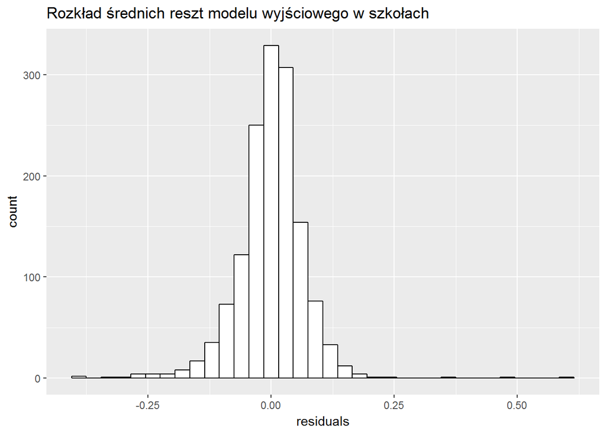

```r
load("Etap7_modelBase.rda")
ggplot(aggregate(residuals ~ school_id, data.frame(residuals = residuals(modelBase), school_id = probka$school_id), mean), aes(x = residuals)) + geom_histogram(binwidth = 0.03, color = "black", fill = "white") + ggtitle("Rozkład średnich reszt modelu wyjściowego w szkołach ")
```

Poniżej przeprowadzamy test ilorazu wiarygodności istotności efektu losowego szkoły: przy każdym sensownym poziomie istotności odrzucamy hipotezę zerową o nieistotności tego efektu. Ponadto, oba kryteria informacyjne wskazują na model z efektem losowym jako na lepszy.

```r
# modelRanSchool <- lmer(time.bc ~ score*(task + edu_resources + no_of_books + wealth + book_id + father_edu_num + father_edu_na) + mother_edu + female + country + (1 | school_id), data = probka, REML = FALSE)
# save(modelRanSchool, file = "Etap7_modelRanSchool.rda")
load("Etap7_modelRanSchool.rda")
as.data.frame(anova(modelRanSchool, modelBase)); rm(modelBase)
```

```
##                 Df    AIC    BIC logLik deviance Chisq Chi Df Pr(>Chisq)
## modelBase      322 102391 105836 -50874   101747    NA     NA         NA
## modelRanSchool 323  94644  98099 -46999    93998  7749      1          0
```

### 3.1.2 Losowy współczynnik nachylenia

Oprócz losowego wyrazu wolnego w modelu mieszanym możemy również uwzględnić losowy współczynnik nachylenia dla wybranych zmiennych, przy czym dodanie go dla zmiennej jakościowej oznacza dodanie efektu losowego dla każdego poziomu tej zmiennej. Ze względu na fakt, że nie umiemy a priori stwierdzić, które nachylenia powinny być losowe musimy dojść do tego metodą prób i błędów. Dla zmiennych jakościowych istotnie komplikuje to model, więc ograniczymy się do trzech zmiennych ciągłych `edu_resources`, `wealth` oraz `father_edu_num`.

Poniżej prezentujemy wykresy zależności liniowych między resztami modelu wyjściowego a każdą ze zmiennych ciągłych dla 25 wylosowanych szkół.

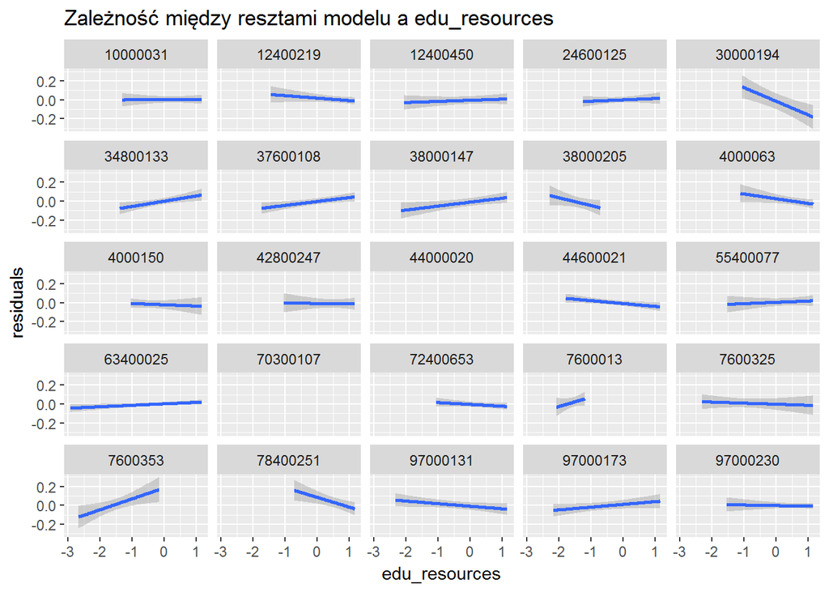

```r
set.seed(2017)
index <- probka$school_id %in% sample(levels(probka$school_id), size = 25)
data <- probka[index, ]; data$school_id <- droplevels(data$school_id)
data$residuals <- residuals(modelRanSchool)[index]
ggplot(data, aes(x = edu_resources, y = residuals)) + geom_smooth(method = "lm") + facet_wrap( ~school_id) + ggtitle("Zależność między resztami modelu a edu_resources")
```

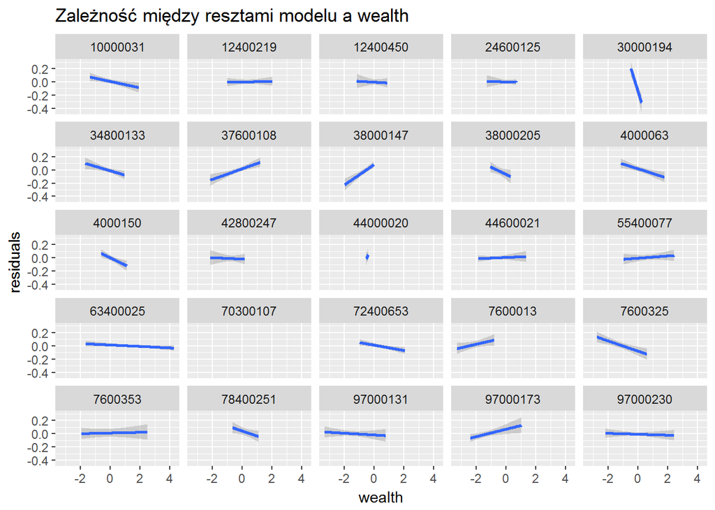

```r
ggplot(data, aes(x = wealth, y = residuals)) + geom_smooth(method = "lm") + facet_wrap( ~school_id) + ggtitle("Zależność między resztami modelu a wealth")
```

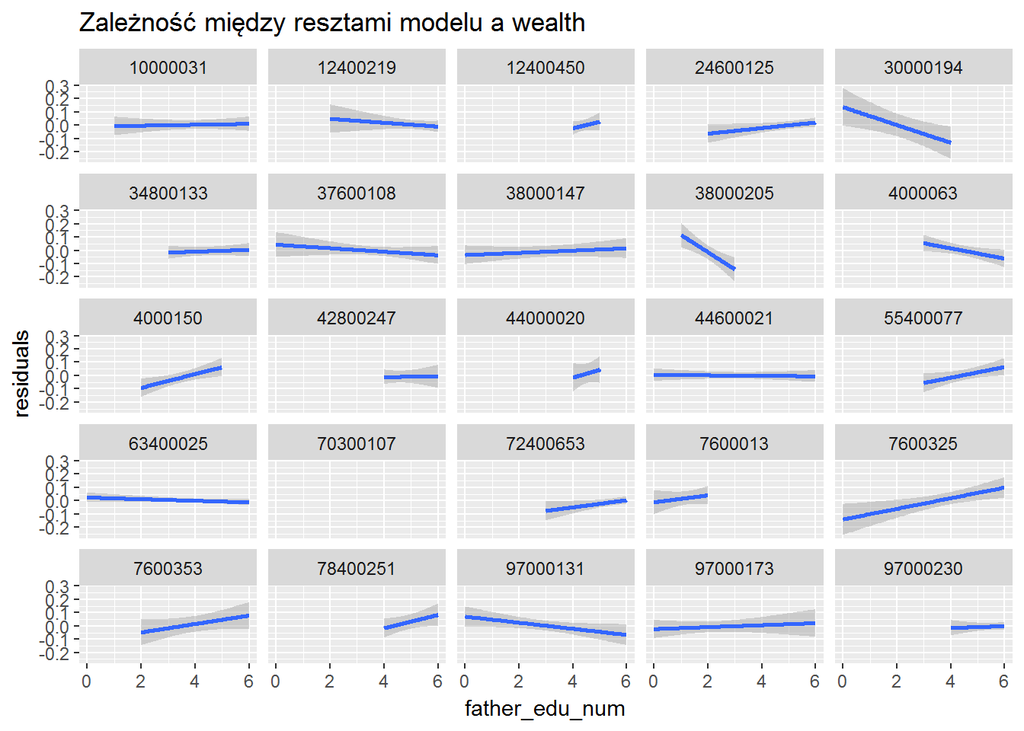

```r
ggplot(data, aes(x = father_edu_num, y = residuals)) + geom_smooth(method = "lm") + facet_wrap( ~school_id) + ggtitle("Zależność między resztami modelu a wealth"); rm(data, index)
```

Jak widać nachylenia prostych regresji nie tylko wyraźnie różnią się między szkołami, ale również mają różne znaki, a więc uwzględnienie losowego współczynnika nachylenia wydaje się uzasadnione. Poniżej robimy to kolejno dla każdej z trzech zmiennych.

```r
fixed_formula <- "time.bc ~ score*(task + edu_resources + no_of_books + wealth + book_id + father_edu_num + father_edu_na) + mother_edu + female + country"
losowy <- "school_id"
for(i in c("edu_resources", "wealth", "father_edu_num")){
  model <- lmer(as.formula(paste(c(fixed_formula, paste0("(1 | ", paste0(losowy, ")")), "(-1", paste0(paste0(i, " | "), paste0(losowy, " )"))), collapse = " + ")), data = probka, REML = FALSE)
  print(paste(c("Test istotności losowego nachylenia", i, "ze względu na szkołę"), collapse = " "))
  print(as.data.frame(anova(model, modelRanSchool, refit = FALSE)))
}
```

```
## [1] "Test istotności losowego nachylenia edu_resources ze względu na szkołę"
##                 Df   AIC   BIC logLik deviance Chisq Chi Df Pr(>Chisq)
## modelRanSchool 323 94644 98099 -46999    93998    NA     NA         NA
## model          324 92802 96268 -46077    92154  1844      1          0
## [1] "Test istotności losowego nachylenia wealth ze względu na szkołę"
##                 Df   AIC   BIC logLik deviance Chisq Chi Df Pr(>Chisq)
## modelRanSchool 323 94644 98099 -46999    93998    NA     NA         NA
## model          324 92760 96226 -46056    92112  1886      1          0
## [1] "Test istotności losowego nachylenia father_edu_num ze względu na szkołę"
##                 Df   AIC   BIC logLik deviance Chisq Chi Df Pr(>Chisq)
## modelRanSchool 323 94644 98099 -46999    93998    NA     NA         NA
## model          324 93867 97333 -46610    93219 779.1      1 1.895e-171
```

Niezależnie od zmiennej, dla której je dodamy, losowe nachylenie jest istotne w modelu według testu ilorazu wiarygodności i znacznie obniża wartości obu kryteriów informacyjnych. Obniżka ta jest najwyższa w przypadku zmiennej `wealth`. Poniżej sprawdzamy czy uwzględnienie losowego nachylenia zarówno dla `wealth` jak i dla jednej z pozostałych zmiennych poprawia nasz model:

```r
rm(list = ls()); load("Projekt_probka.rda")
model <- lmer(time.bc ~ score*(task + edu_resources + no_of_books + wealth + book_id + father_edu_num + father_edu_na) + mother_edu + female + country + (1 + wealth | school_id), data = probka, REML = FALSE)
model1 <- lmer(time.bc ~ score*(task + edu_resources + no_of_books + wealth + book_id + father_edu_num + father_edu_na) + mother_edu + female + country + (1 + wealth + edu_resources | school_id), data = probka, REML = FALSE)
as.data.frame(anova(model1, model, refit = FALSE))
```

```
##         Df   AIC   BIC logLik deviance Chisq Chi Df Pr(>Chisq)
## model  325 92742 96218 -46046    92092    NA     NA         NA
## model1 328 91177 94686 -45261    90521  1571      3          0
```

```r
model1 <- lmer(time.bc ~ score*(task + edu_resources + no_of_books + wealth + book_id + father_edu_num + father_edu_na) + mother_edu + female + country + (1 + wealth + father_edu_num | school_id), data = probka, REML = FALSE)
as.data.frame(anova(model1, model, refit = FALSE)); rm(model, model1)
```

```
##         Df   AIC   BIC logLik deviance Chisq Chi Df Pr(>Chisq)
## model  325 92742 96218 -46046    92092    NA     NA         NA
## model1 328 91212 94721 -45278    90556  1535      3          0
```

Na podstawie powyższych tabelek stwierdzamy, że choć każdy dodany współczynnik nachylenia jest istotny statystycznie, to przy dodaniu go dla `edu_resources` bardziej poprawiamy kryteria informacyjne niż dla `father_edu_num` (oprócz tego w drugim przypadku model okazał się prawie nieidentyfikowalny), natomiast uwzględnienie obu losowych nachyleń (oprócz `wealth`) byłoby przesadną komplikacją przy niewielkiej poprawie jakości modelu.

## 3.2 Efekt losowy ucznia

Podobnie jak w przypadku szkoły domyślamy się, że występuje pewien “efekt ucznia” – niektórzy uczniowie mogą być wyjątkowi pod względem szybkości rozwiązywania zadań, np. wyjątkowo szybko czytają polecenia. Z tego względu rozważymy losowe wyrazy wolne i współczynniki nachylenia ze względu na uczniów w taki sam sposób, jak robiliśmy to dla szkół, przy czym zaczynamy znowu od modelu wyjściowego `modelBase`, a wyniki porównamy z wynikami dla efektów losowych szkoły w punkcie 3.3.

### 3.2.1 Losowy wyraz wolny

Podobnie jak dla szkół, poniżej przedstawiamy rozkład średnich reszt modelu w grupach ze względu na uczniów. Jest on podobny do normalnego, choć wyraźnie niesymetryczny. Mimo to, spróbujemy włączyć losowy wyraz wolny dla uczniów, zakładając jego normalność.

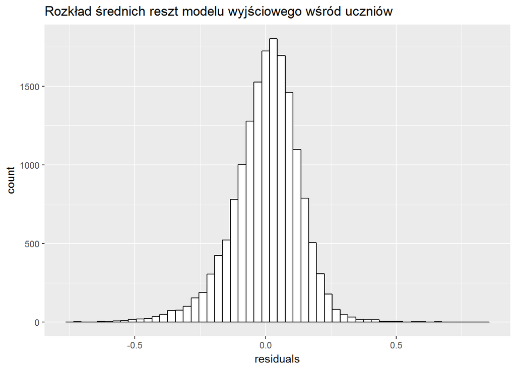

```r
load("Etap7_modelBase.rda")
ggplot(aggregate(residuals ~ student_id, data.frame(residuals = residuals(modelBase), student_id = probka$student_id), mean), aes(x = residuals)) + geom_histogram(binwidth = 0.03, color = "black", fill = "white") + ggtitle("Rozkład średnich reszt modelu wyjściowego wśród uczniów")
```

Poniżej weryfikujemy istotność efektu losowego – widać, że jest istotny i poprawia oba kryteria informacyjne znacznie bardziej niż uwzglednienie analogicznego efektu dla szkoły. Jest to prawdopodobnie spowodowane znacznie większą liczbą uczniów niż szkół, zatem uwzględniając zróżnicowanie uczniów możemy objaśnić więcej zmienności przy tej samej liczbie parametrów.

```r
# modelRanStudent <- lmer(time.bc ~ score*(task + edu_resources + no_of_books + wealth + book_id + father_edu_num + father_edu_na) + mother_edu + female + country + (1 | student_id), data = probka, REML = FALSE)
# save(modelRanStudent, file = "Etap7_modelRanStudent.rda")
load("Etap7_modelRanStudent.rda")
as.data.frame(anova(modelRanStudent, modelBase)); rm(modelBase)
```

```
##                  Df    AIC    BIC logLik deviance Chisq Chi Df Pr(>Chisq)
## modelBase       322 102391 105836 -50874   101747    NA     NA         NA
## modelRanStudent 323  73032  76487 -36193    72386 29361      1          0
```

### 3.2.2 Losowy współczynnik nachylenia

Teraz rozważamy losowe współczynniki nachylenia zmiennych `edu_resources`, `wealth` i `father_edu_num`. Należy pamiętać, że wszystkie te zmienne przyjmują jedną wartość dla każdego ucznia, więc losowe nachylenie ma w tym przypadku znacznie mniej sensu niż dla szkół.

```r
fixed_formula <- "time.bc ~ score*(task + edu_resources + no_of_books + wealth + book_id + father_edu_num + father_edu_na) + mother_edu + female + country"
losowy <- "student_id"
for(i in c("edu_resources", "wealth", "father_edu_num")){
  model <- lmer(as.formula(paste(c(fixed_formula, paste0("(1 | ", paste0(losowy, ")")), "(-1", paste0(paste0(i, " | "), paste0(losowy, " )"))), collapse = " + ")), data = probka, REML = FALSE)
  print(paste(c("Test istotności losowego nachylenia", i, "ze względu na ucznia"), collapse = " "))
  print(as.data.frame(anova(model, modelRanStudent, refit = FALSE)))
}
```

```
## [1] "Test istotności losowego nachylenia edu_resources ze względu na ucznia"
##                  Df   AIC   BIC logLik deviance Chisq Chi Df Pr(>Chisq)
## modelRanStudent 323 94644 98099 -46999    93998    NA     NA         NA
## model           324 72899 76365 -36126    72251 21747      1          0
## [1] "Test istotności losowego nachylenia wealth ze względu na ucznia"
##                  Df   AIC   BIC logLik deviance Chisq Chi Df Pr(>Chisq)
## modelRanStudent 323 94644 98099 -46999    93998    NA     NA         NA
## model           324 72871 76337 -36112    72223 21775      1          0
## [1] "Test istotności losowego nachylenia father_edu_num ze względu na ucznia"
##                  Df   AIC   BIC logLik deviance Chisq Chi Df Pr(>Chisq)
## modelRanStudent 323 94644 98099 -46999    93998    NA     NA         NA
## model           324 73034 76500 -36193    72386 21612      1          0
```

## 3.3 Efekt losowy ucznia zagnieżdżonego w szkole

Do tej pory stwierdziliśmy, że zarówno model z efektem losowym dla szkoły jak i ten z efektem losowym dla ucznia jest lepszy niż wyjściowy, przy czym drugi z nich jest lepszy od pierwszego. Teraz rozważymy dodanie obu efektów losowych, co w tym przypadku prowadzi do powstania hierarchicznego modelu mieszanego ze względu na zagnieżdżenie uczniów w szkołach.

```r
rm(list = ls())
# modelRanBothNested <- lmer(time.bc ~ score*(task + edu_resources + no_of_books + wealth + book_id + father_edu_num + father_edu_na) + mother_edu + female + country + (1 | school_id/student_id), data = probka, REML = FALSE)
# save(modelRanBothNested, file = "Etap7_modelRanBothNested.rda")
load("Etap7_modelRanBothNested.rda"); load("Etap7_modelRanSchool.rda")
as.data.frame(anova(modelRanBothNested, modelRanSchool))
```

```
##                     Df   AIC   BIC logLik deviance Chisq Chi Df Pr(>Chisq)
## modelRanSchool     323 94644 98099 -46999    93998    NA     NA         NA
## modelRanBothNested 324 72353 75819 -35853    71705 22293      1          0
```

Powyższy test ilorazu wiarygodności wskazuje na istotność dodatkowego efektu losowego. W następnym kroku dodajemy do otrzymanego modelu losowe współczynniki nachylenia dla zmiennych `wealth`i `edu_resources`, które wybraliśmy w punkcie 3.1.2, przy czym tym razem pozwalamy na niezerową korelację między efektami losowymi.

```r
rm(modelRanSchool)
# modelRanBothNestedPlus <- lmer(time.bc ~ score*(task + edu_resources + no_of_books + wealth + book_id + father_edu_num + father_edu_na) + mother_edu + female + country + (1 + wealth + edu_resources | school_id/student_id), data = probka, REML = FALSE)
# save(modelRanBothNestedPlus, file = "Etap7_modelRanBothNestedPlus.rda")
load("Etap7_modelRanBothNestedPlus.rda")
as.data.frame(anova(modelRanBothNestedPlus, modelRanBothNested))
```

```
##                         Df   AIC   BIC logLik deviance Chisq Chi Df
## modelRanBothNested     324 72353 75819 -35853    71705    NA     NA
## modelRanBothNestedPlus 334 72068 75641 -35700    71400 305.6     10
##                        Pr(>Chisq)
## modelRanBothNested             NA
## modelRanBothNestedPlus  1.007e-59
```

```r
rm(modelRanBothNestedPlus, modelRanBothNested)
```

# 4 Wybrany model

## 4.1 Estymacja

Po uwzględnieniu efektu losowego kwestionariusza omówionego w punkcie 2.2.4 otrzymujemy następujący model:

```r
# modelChosen <- lmer(time.bc ~ score*(task + edu_resources + no_of_books + wealth + father_edu_num + father_edu_na) + mother_edu + female + country + (1 + score | book_id) + (1 + wealth + edu_resources | school_id/student_id), data = probka, REML = FALSE)
# save(modelChosen, file = "Etap7_modelChosen.rda")
# load("Etap7_modelChosen.rda")
```

Niestety oszacowanie parametrów powyższego modelu nie udało się – algorytm nie osiągnął zbieżności. Z tego względu usuwamy z modelu element, który podczas selekcji przyniósł najmniejszą poprawę kryteriów informacyjnych czyli losowe nachylenie dla `edu_resources`. W ten sposób otrzymujemy następujący model, który porównujemy z modelem wyjściowym po zamianie efektu `book_id` ze stałego na losowy:

```r
# modelChosen2 <- lmer(time.bc ~ score*(task + edu_resources + no_of_books + wealth + father_edu_num + father_edu_na) + mother_edu + female + country + (1 + score | book_id) + (1 + wealth | school_id/student_id), data = probka, REML = FALSE)
# save(modelChosen2, file = "Etap7_modelChosen2.rda")
load("Etap7_modelRanBook.rda"); load("Etap7_modelChosen2.rda")
as.data.frame(anova(modelChosen2, modelRanBook))
```

```
##               Df    AIC    BIC logLik deviance Chisq Chi Df Pr(>Chisq)
## modelRanBook 223 102549 104934 -51051   102103    NA     NA         NA
## modelChosen2 229  72271  74721 -35907    71813 30289      6          0
```

Jak widać dodanie losowego wyrazu wolnego i nachylenia `wealth` w zależności od ucznia zagnieżdżonego w szkole wyraźnie poprawiło jakość naszego modelu (ale też wielokrotnie wydłużyło czas estymacji).

## 4.2 Wizualizacja oszacowań

W celu wizualizacji otrzymanych oszacowań szacujemy parametry naszego modelu ponownie, tym razem metodą REML, domyślną dla takich modeli. Ze względu na występujące w modelu liczne interakcje efektów stałych ze zmienną `score` tworzymy funkcję `coefs_score()`, która dla współczynników modelu zwraca te współczynniki skorygowane o współczynnik dla odpowiedniego poziomu `score`.

```r
# modelChosen2 <- lmer(time.bc ~ score*(task + edu_resources + no_of_books + wealth + father_edu_num + father_edu_na) + mother_edu + female + country + (1 + score | book_id) + (1 + wealth | school_id/student_id), data = probka)
# save(modelChosen2, file = "Etap7_modelChosen2_REML.rda")
rm(list = ls()); load("Projekt_probka.rda")
load("Etap7_modelChosen2_REML.rda")
coefs_score <- function(x){
  coefs <- data.frame(beta = x, variable = gsub("score.+:", "", names(x)), score = "No credit")
  coefs$score <- as.character(coefs$score)
  coefs$score[grep("score.+:", rownames(coefs))] <- rownames(coefs)[grep("score.+:", rownames(coefs))]
  coefs$score <- gsub("score", "", coefs$score)
  coefs$score <- gsub(":.+", "", coefs$score)
  coefs$score[c(1:3, grep("country", rownames(coefs)), grep("female", rownames(coefs)), grep("mother_edu", rownames(coefs)))] <- NA
  rownames(coefs) <- NULL
  coefs$score <- factor(coefs$score, levels = c("-1", "No credit", "Full credit"))
  coefs$beta_score <- NA
  coefs[grep("-1", as.character(coefs$score)), "beta_score"] <- coefs$beta[grep("-1", as.character(coefs$score))] + coefs$beta[2]
  coefs[grep("Full credit", as.character(coefs$score)), "beta_score"] <- coefs$beta[grep("Full credit", as.character(coefs$score))] + coefs$beta[3]
  coefs[grep("No credit", as.character(coefs$score)), "beta_score"] <- coefs$beta[grep("No credit", as.character(coefs$score))]
  coefs$variable <- as.character(coefs$variable)
  return(coefs)
}
coefs <- coefs_score(fixef(modelChosen2))
```

Spośród oszacowań efektów stałych naszego modelu interesujące wydają się parametry dla poszczególnych krajów (Polska jest tu poziomem bazowym):

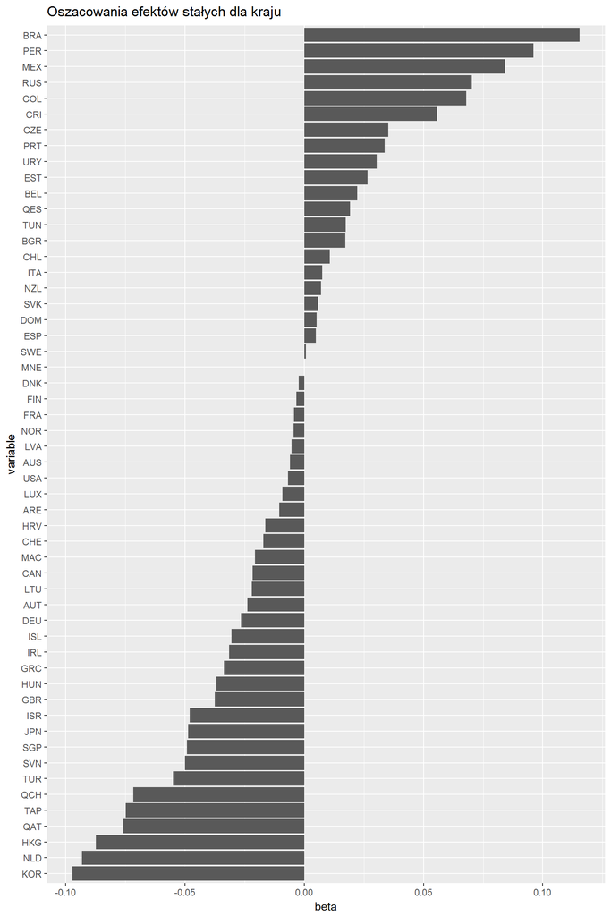

```r
df <- coefs[grep("country", coefs$variable), ]
df$variable <- gsub("country", "", df$variable)
df$variable <- factor(df$variable, levels = df[order(df$beta), "variable"])
ggplot(df, aes(y = beta, x = variable)) + geom_bar(stat = "identity") +  ggtitle("Oszacowania efektów stałych dla kraju") + coord_flip()
```

Ponadto, zależność czasu rozwiązywania zadań od liczby książek wyraźnie zależy od punktacji zadania:

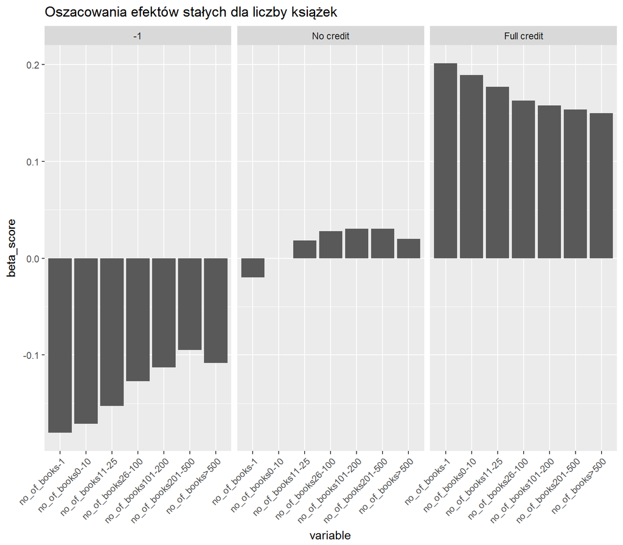

```r
df <- coefs[c(2:3, grep("no_of_books", coefs$variable)), ]; df$beta_score[1:2] <- df$beta[1:2]
df$score[1:2] <- c("-1", "Full credit"); df$variable[1:2] <- paste0("no_of_books", "0-10")
df$variable <- factor(df$variable, levels = paste0("no_of_books", c("-1", levels(probka$no_of_books)[-2])))
ggplot(df, aes(y = beta_score, x = variable)) + geom_bar(stat = "identity") + facet_wrap(~ score) + theme(axis.text.x=element_text(angle = 45, hjust = 1)) + ggtitle("Oszacowania efektów stałych dla liczby książek")
```

Na powyższym wykresie widać, że wpływ kolejnych kategorii liczby książek na czas rozwiązywania zmienia się monotonicznie, przy czym: jest coraz większy (coraz mniej ujemny) dla osób, dla których nie ma informacji o wyniku zadania – dla tych osób im więcej książek w domu, tym dłuższy czas rozwiązywania zadania. Dla osób, które dobrze rozwiązały zadanie jest odwrotnie – im więcej książek w domu, tym szybciej rozwiązują one zadanie. Z kolei dla osób, które nie dostały punktów za zadanie wpływ liczby książek na czas rozwiązywania jest bliski zera. Co ciekawe, monotoniczność efektów kolejnych kategorii nie jest zachowana przez kategorię wskazującą na ponad 500 książek w domu, co sugeruje, że osoby zaznaczające tę kategorię w pewien sposób różnią się od pozostałych, być może stanowią po prostu bardziej zróżnicowaną grupę niż pozostałe.

Komponenty losowe naszego modelu są następujące:

```r
summary(modelChosen2)$varcor
```

```
##  Groups               Name             Std.Dev. Corr
##  student_id:school_id (Intercept)      0.09819
##                       wealth           0.03350  -0.04
##  school_id            (Intercept)      0.04650
##                       wealth           0.00497  0.20
##  book_id              (Intercept)      0.05098
##                       score-1          0.02079   0.72
##                       scoreFull credit 0.01388  -0.99 -0.83
##  Residual                              0.26002
```

Jak widać najwyższą wariancję wśród efektów losowych ma wyraz wolny dla ucznia – wariancja wyrazu wolnego dla szkoły jest ponad dwukrotnie mniejsza, co oznacza, że zróżnicowanie między uczniami przyczynia się do dużej zmienności naszej zmiennej. Losowy wyraz wolny dla szkół ma nawet mniejszą wariancję od losowego wyrazu wolnego dla kwestionariusza, co oznacza, że zróżnicowanie jest również znaczące między poszczególnymi kwestionariuszami.

## 4.3 Testy permutacyjne

Poniżej wykonujemy testy permutacyjne istotności efektów losowych szkoły i ucznia w celu uzupełnienia dotychczasowych wyników. Ze względu na dość skomplikowaną strukturę naszych efektów losowych i występowanie zarówno losowych wyrazów wolnych jak i potencjalnie niezerowych korelacji między nimi, testowanie wykonamy na trochę prostszym modelu, w którym jedynymi efektami losowymi szkoły i ucznia są losowe wyrazy wolne.

### 4.3.1 Test efektu ucznia

Najpierw testujemy isotność losowego efektu ucznia, przy czym przy permutacji wartości tej zmiennej musimy pamiętać o strukturze hierarchicznej naszego modelu. Wykonujemy 19 replikacji testu, co razem z oszacowaniem bez permutacji daje 20 obserwacji i oszacowana wariancja z tego ostatniego będzie największa, to przy poziomie istotności 0.05 możemy odrzucić hipotezę zerową o nieistotności efektu losowego ucznia.

```r
rm(list = ls()); load("Projekt_probka.rda")
modelTesting <- lmer(time.bc ~ score*(task + edu_resources + no_of_books + wealth + father_edu_num + father_edu_na) + mother_edu + female + country + (1 + score | book_id) + (1 | school_id) + (1 | school_id:student_id), data = probka)
save(modelTesting, file = "Etap7_modelTesting.rda")
data <- probka
wynik <- replicate(19, {
    probka[, c("school_id_perm", "student_id_perm")] <- probka[sample(1:nrow(probka)), c("school_id", "student_id")]
    model <- lmer(time.bc ~ score*(task + edu_resources + no_of_books + wealth + father_edu_num + father_edu_na) + mother_edu + female + country + (1 + score | book_id) + (1 | school_id) + (1 | school_id_perm:student_id_perm), data = probka)
    as.data.frame(summary(model)$varcor)[1, 4]
})
save(wynik, file = "Etap7_test_efektu_studenta.rda")
```

Poniżej sprawdzamy, czy maksymalna wariancja losowego wyrazu wolnego po permutacji uczniów zagnieżdżonych w szkołach jest niższa od tejże wariancji w naszym modelu (bez permutacji):

```r
load("Etap7_test_efektu_studenta.rda"); load("Etap7_modelTesting.rda")
max(wynik) < as.data.frame(summary(modelTesting)$varcor)[1, 4]
```

```
## [1] TRUE
```

Widać, że przy poziomie istotności 0.05 nasz efekt losowy jest istotny. Co więcej, jego wariancja w modelu wyniosła 0.0113 czyli kilkakrotnie więcej niż ta wariancja po permutacji 1.230510^{-4}, a więc mimo małej liczby replikacji, możemy spokojnie stwierdzić, że efekt losowy ucznia jest istotny.

### 4.3.2 Test efektu szkoły

Podobną procedurę przeprowadzamy dla efektu losowego szkoły:

```r
wynik <- replicate(19, {
    probka[, "school_id_perm"] <- probka[sample(1:nrow(probka)), "school_id"]
  model <- lmer(time.bc ~ score*(task + edu_resources + no_of_books + wealth + father_edu_num + father_edu_na) + mother_edu + female + country + (1 + score | book_id) + (1 | school_id_perm) + (1 | school_id:student_id), data = probka)
    as.data.frame(summary(model)$varcor)[2, 4]
})
save(wynik, file = "Etap7_test_efektu_szkoly.rda")
```

Porównujemy maksymalną wariancję efektu po permutacji do wariancji w naszym modelu:

```r
load("Etap7_test_efektu_szkoly.rda")
max(wynik) < as.data.frame(summary(modelTesting)$varcor)[2, 4]
```

```
## [1] TRUE
```